# Ecological Models and Data Analysis – Chapter 6 — Ecological Models and Data Analysis

## Ecological Models and Data Analysis

Chapter 6 · Lecture

Fitting Ecological Response Curves

## Overview of the lecture

1. **The model:** how does a predictor enter a distribution?
2. **The fit:** what changes from Chapter 4?
3. **Uncertainty:** how precise are the parameters, and the curve?
4. **Checking:** does the model describe the data?
5. **Revision and comparison:** which model do the data support?
6. **The practical:** what comes next?

## Two pillars: functions and distributions

### Distributions and likelihood

Chapters 2 to 4: a distribution for the observations, its parameters estimated by maximum likelihood.

### Deterministic functions

Chapter 5: curves that describe how an expected response changes with a predictor.

Reed frog tadpoles: 16 tanks with 5 to 100 tadpoles each; the number killed by dragonfly larvae in 14 days.

A curve gives a parameter of the distribution of each observation.

## A response curve as a parameter of a distribution

$$\theta_i=f(x_i;\boldsymbol\beta)$$

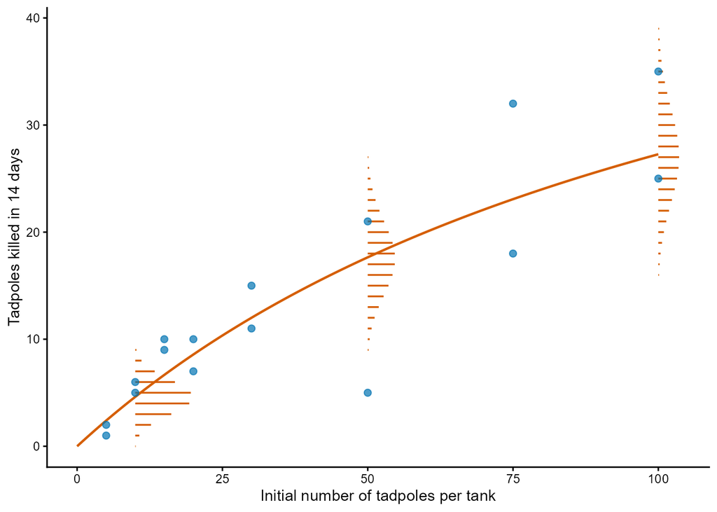

- **One distribution per observation:** its parameter is the curve at its own $x_i$.
- **Other parameters:** often shared.
- **Independent:** but not identically distributed.
- **The observation model:** a choice, like the curve.

$Y_i\sim\operatorname{Binomial}\left(N_i,p(N_i)\right)$, with $p(N)=\alpha/(1+\alpha HN)$

Blue: the 16 tanks. Line: expected number killed with the values read by eye in Chapter 5 ($\alpha=0.5$, $H=1/60$). Bars: Binomial probabilities at 10, 50 and 100 tadpoles.

## What the curve must return

| Distribution | Parameter and its range | A curve with that range |
| --- | --- | --- |
| Normal | mean $\mu$: any value | any curve |
| Poisson, Negative Binomial | mean $\mu$: positive | positive, or `exp()` of a curve |
| Binomial | probability $p$: 0 to 1 | between 0 and 1, or `plogis()` of a curve |

The Binomial needs a probability, so the curve gives $p(N)$; the expected number killed, $N\,p(N)=\alpha N/(1+\alpha HN)$, is the disc equation of Chapter 5. With $0<\alpha<1$ and $H>0$, $p(N)$ lies between 0 and $\alpha$.

The range of the curve is part of the model.

## Practice 1: seedlings and light

**3 minutes:** on paper.

The number of tree seedlings in a quadrat is described with a Poisson distribution whose parameter follows a curve of the light that reaches the soil, $x$ (% of full sunlight).

1. Which parameter does the curve describe, and which values must it return?
2. Could the straight line $a+bx$ be used for every value of $a$ and $b$?
3. Could $ax/(b+x)$ with positive $a$ and $b$, if some quadrats have no light at all?

## The likelihood of a response curve

$$\ell(\boldsymbol\theta)=\sum_{i=1}^{n}\log\left(P(Y_i=y_i\mid\boldsymbol\theta)\right)$$

- **Each observation:** its probability, with the parameter given by the curve at its own $x_i$.
- **All the parameters, $\boldsymbol\theta$:** those of the curve, $\boldsymbol\beta$, and any shared parameter of the distribution.
- **The same machinery as Chapter 4:** two lists, transformations, `cmb()`, `MakeADFun()`, `optim()`.
- **New:** the predictor goes in the list of data; starting values come from a plot.

One tank: $\log\left(\binom{N_i}{Y_i}\,p(N_i)^{Y_i}\left(1-p(N_i)\right)^{N_i-Y_i}\right)$, summed over the 16 tanks.

## The negative log-likelihood in R

- **List of data:** the predictor and the response.
- **Transformations:** `plogis()` for a probability, `exp()` for a positive parameter.
- **The curve:** one value per observation (a vector).
- **Log probabilities:** each with its own trials and probability.

```r
# Predictor and response in the list of data.
frog_data = list(
  initial = ReedfrogFuncresp$Initial,
  killed = ReedfrogFuncresp$Killed
)

binomial_nll = function(parms, data) {
  getAll(parms, data)
  alpha = plogis(logit_alpha)
  H = exp(log_H)
  # Probability that a tadpole is killed,
  # at the density of each tank.
  p = alpha / (1 + alpha * H * initial)
  -sum(dbinom(x = killed, size = initial,
              prob = p, log = TRUE))
}
```

## Starting values and the fit

- **Starting values:** read by eye from a plot (Chapter 5), on the transformed scale.
- **`MakeADFun()`:** the NLL connected to the data with `cmb()`.
- **`optim()`:** BFGS with `gr`; check `convergence`.
- **Transform back:** the estimates on the original scale.

```r
# Start from the values read by eye in Chapter 5.
binomial_obj = MakeADFun(
  cmb(binomial_nll, frog_data),
  list(logit_alpha = qlogis(0.5),
       log_H = log(1 / 60)),
  silent = TRUE
)
binomial_fit = optim(
  par = binomial_obj$par, fn = binomial_obj$fn,
  gr = binomial_obj$gr, method = "BFGS"
)
binomial_fit$convergence  # 0

# 0.526 per experiment; 0.0166 experiments
# per tadpole killed.
plogis(binomial_fit$par["logit_alpha"])
exp(binomial_fit$par["log_H"])
```

## Reading the fitted curve

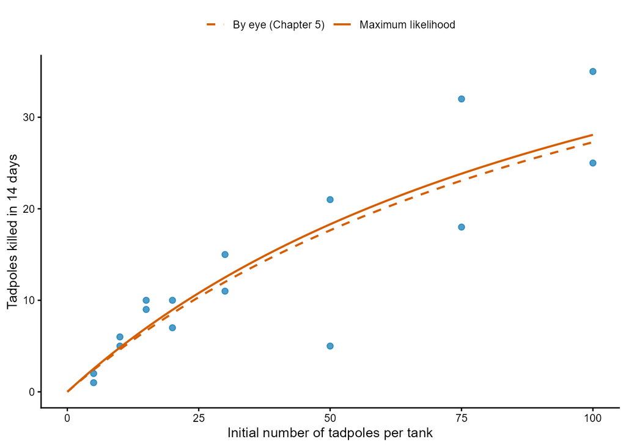

- **Points:** the observations. **Line:** the expected response under the fitted model.
- **Invariance:** quantities of the curve, such as its asymptote and half-maximum, follow from the estimates of its parameters.
- **Convergence** is the first check; residuals come next.

Asymptote $1/\hat H$: about 60 tadpoles killed. Half-maximum $1/(\hat\alpha\hat H)$: about 115 tadpoles per tank. By eye: 60 and 120.

Solid: maximum likelihood. Dashed: the values read by eye in Chapter 5.

## The gradient and automatic differentiation

**Gradient:** the vector of partial derivatives of the NLL with respect to the parameters, its slope in the direction of each parameter.

- **Automatic differentiation:** RTMB differentiates the code of the NLL, exactly up to rounding error, without a formula from us.
- **BFGS:** uses it at every step; correlated parameters make a narrow, tilted valley, where an inexact gradient can stop the search early.
- **Also behind** `sdreport()`, `ADREPORT()` and random effects (Chapter 7).
- **Requirement:** functions that RTMB knows; an `if` on a parameter is refused.

`binomial_obj$gr()`: $-4.30$ and $3.20$ at the starting values; close to zero at the estimates.

## Precision and correlation of curve parameters

- **`sdreport()`:** standard errors and covariance matrix, as in Chapter 4.
- **Correlated estimates:** different combinations of parameters give similar curves over the range of the data.
- **Parameterisation:** changes the correlation and not the fit.

```r
binomial_sd = sdreport(binomial_obj)
summary(binomial_sd)
#             Estimate Std. Error
# logit_alpha    0.104      0.285
# log_H         -4.098      0.294

cov2cor(binomial_sd$cov.fixed)  # 0.82
```

Correlation 0.82 between $\operatorname{logit}(\hat\alpha)$ and $\log(\hat H)$; 0.98 between $\log(\hat a)$ and $\log(\hat b)$ of the Michaelis–Menten form, because the tanks determine mainly the initial slope, $a/b=\alpha$.

## Where the data lie

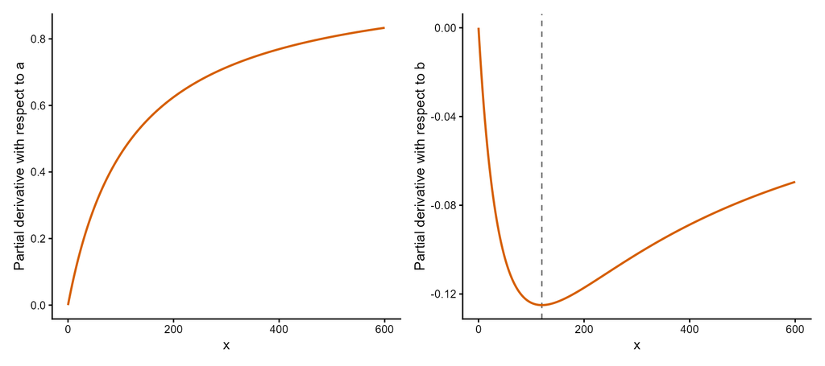

Partial derivatives of $ax/(b+x)$ with $a=60$ and $b=120$ (Chapter 5): left, the asymptote $a$; right, the half-maximum $b$ (dashed line). The tanks lie between 5 and 100.

- **Partial derivative:** how much the curve moves at each $x$ when one parameter changes.
- **Observations inform a parameter** where the curve responds to it.
- **Only the rise observed:** initial slope well determined, asymptote poorly.

The design determines what can be estimated.

## Likelihood profile intervals of curve parameters

- **The reference method:** `TMB::tmbprofile()` and `confint()`, as in Chapter 4.
- **Poorly determined parameter:** an asymmetric profile; the data rule out one side more strongly than the other.
- **Transform the endpoints:** any monotonic function; a decreasing one swaps them.

```r
binomial_profile_H = TMB::tmbprofile(binomial_obj, name = "log_H", trace = FALSE)
H_interval = exp(confint(binomial_profile_H))
# Largest number killed, 1 / H: decreasing, so the endpoints swap (37.9 to 143.1).
rev(1 / H_interval)
```

$\alpha$: 0.40 to 0.68 per experiment. $1/H$: about 60 tadpoles killed, from 38 to 143 (Wald from the log scale: 34 to 107). The data rule out a low asymptote, not a high one.

## The uncertainty of a fitted curve

- **A point of the curve:** a quantity calculated from all the parameters.
- **`ADREPORT()` of a vector:** a standard error for every element (TMB applies the delta method).
- **A grid of $x$** in the list of data: the curve at every point of the grid.
- **Wald interval on an unbounded scale** (the logit for a probability), endpoints transformed back.
- **Pointwise:** each interval covers the curve at its own $x$.

```r
# Inside the NLL: the logit of the curve at every density of the grid.
p_grid = alpha / (1 + alpha * H * initial_grid)
logit_p_grid = qlogis(p_grid)
ADREPORT(logit_p_grid)
```

## A confidence band

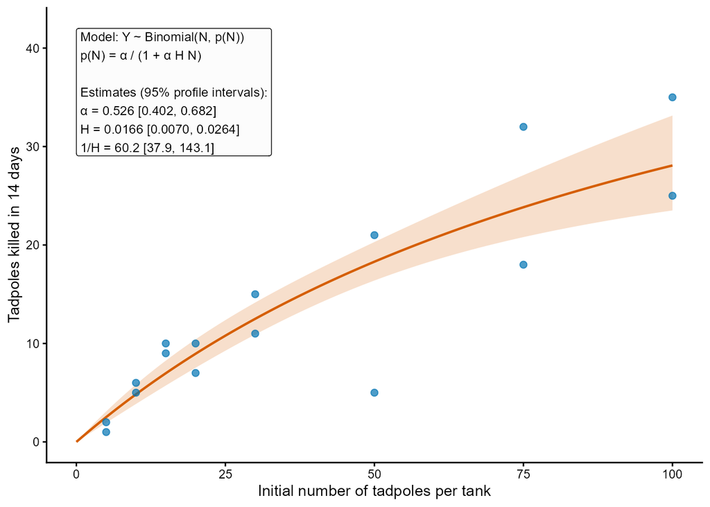

- **Band:** at each $x$, an interval that contains the value of the curve under the data generating process in about 95% of hypothetical samples.
- **Not where observations fall:** that is the distribution around the curve, much wider.
- **Beyond the data:** the band widens quickly.

At 100 tadpoles: 23.5 to 33.1 killed. The curve is well determined within the data, the asymptote is not.

Shaded: pointwise 95% Wald intervals from the logit scale. Inset: the model and the likelihood profile intervals.

## Practice 2: handling time of a ladybird

**3 minutes:** R as a calculator.

A Holling type II curve is fitted to the number of aphids eaten by ladybird larvae in one hour, with the handling time $H$ (hours per aphid) optimised on the log scale. The fit gives $\log(\hat H)=-3.2$, and `sdreport()` gives a standard error of 0.20.

1. Calculate a 95% Wald interval for $H$.
2. From it, calculate an interval for the largest number of aphids eaten per hour, $1/H$.
3. Why are the endpoints swapped in the second interval?

## Simulating from a fitted model

- **Checking:** compare the model’s distribution of every observation with the data; each observation is one value from its own distribution.
- **A fitted model:** a data generating process, with its parameters at the estimates; simulate many values for each observation.
- **`OBS()`** marks the response; **`obj$simulate()`** draws one hypothetical sample, with the same design as the data.
- **Complete observations:** the variation around the curve, not only the curve.

```r
# In the NLL: killed = OBS(killed). Then 1,000 hypothetical samples of the 16 tanks.
n_sim = 1000
binomial_simulations = matrix(NA, nrow = length(frog_data$killed), ncol = n_sim)
set.seed(seed = 601)
for (j in seq_len(n_sim)) {
  binomial_simulations[, j] = binomial_obj$simulate(binomial_fit$par)$killed
}
```

## Scaled quantile residuals

**Scaled quantile residual:** the fraction of the simulated values of an observation that are smaller than the observed value.

- **If the model describes the data generating process:** approximately uniform between 0 and 1, whatever the distribution and the predictor.
- **Ties** (discrete response): the residual is drawn at random between “smaller” and “smaller or equal”.
- **One common scale** for observations with different distributions.
- **`DHARMa::createDHARMa()`:** the simulations, the observations and the expected values.

The tank with 5 of 50 tadpoles killed lies below all its 1,000 simulated values: residual 0.

## Reading residual plots

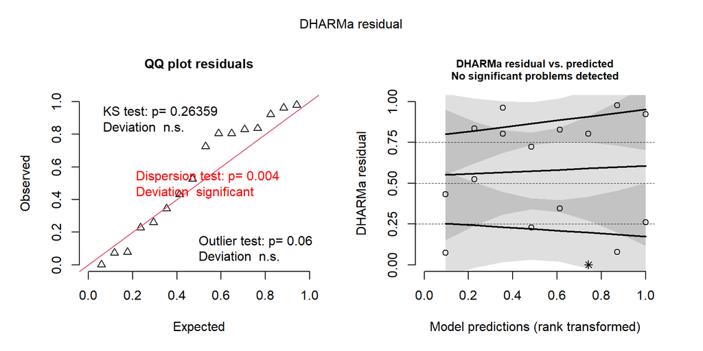

Dispersion statistic 2.9: overdispersion relative to the Binomial. No clear trend with density.

- **Left:** against a uniform distribution; many near 0 and 1: too much spread, near 0.5: too little.
- **Right:** against the fitted values; a trend: the curve misses a change.
- **Exactly 0 or 1:** outliers.
- **Dispersion statistic:** observed / simulated variance, about 1 under the model. Printed tests: exploratory, no decisions on p-values.

A check shows where a model disagrees with the data, not why.

## Discussion: what does a residual pattern tell us?

1. Residuals mostly below 0.5 at low $x$ and mostly above 0.5 at high $x$.
2. Too many residuals near 0 and 1 at every $x$; dispersion statistic 3.
3. Residuals of neighbouring quadrats along a transect are alike.
4. No pattern at all, with eight observations.

Curve · Distribution · Independence · Cannot tell

**3 minutes:** label each pattern with a neighbour.

## Live demo: the modelling cycle for one model

1. **The NLL and the fit:** the predictor in the list of data, starting values by eye, the gradient, convergence.
2. **Estimates and the curve:** back-transformed and drawn over the data.
3. **Uncertainty of the parameters:** `sdreport()`, the correlation, a likelihood profile.
4. **Uncertainty of the curve:** `ADREPORT()` on a grid, the band.
5. **Checking:** `obj$simulate()` and scaled quantile residuals.

**Script:** `demo-cycle.R`, sections 1 to 5 (section 0 during the break): the Binomial model with the Holling type II curve; no model comparison.

## Revising the observation model

$$E[Y]=Np,
\qquad
\operatorname{Var}(Y)=Np(1-p)\,\frac{\kappa+N}{\kappa+1}$$

- **Beta-Binomial:** the probability varies among sampling units; mean $p$ from the curve, precision $\kappa$.
- **Large $\kappa$:** close to a Binomial. The factor grows with the number of trials $N$.
- **In R:** `dbetabinom()` with shapes $\kappa p$ and $\kappa(1-p)$; the curve is unchanged.

$\hat\alpha\approx0.54$, $\hat H\approx0.018$, $\hat\kappa\approx26$; standard errors 0.38 and 0.46 (Binomial: 0.29 for both); dispersion statistic 0.92.

When units vary, the information depends more on the number of units than on the number of trials.

## Practice 3: fruit set in inflorescences

**3 minutes:** on paper.

Each inflorescence of a shrub has 20 flowers, and the mean probability that a flower sets fruit is 0.4.

1. Calculate the variance of the number of fruits per inflorescence under a Binomial model and under a Beta-Binomial model with $\kappa=5$.
2. Which value of $\kappa$ would make the variance of the Beta-Binomial model only 10% larger than that of the Binomial model?

## Candidate models

- **Plausible alternatives:** ecological or statistical, fitted in a loop.
- **The same observations:** the same rows, response and units.
- **Nested:** a special case obtained by fixing a parameter of another model.
- **Log-likelihood alone:** highest for the model with most parameters, so a penalty for $K$ is needed.

| Curve | Binomial | Beta-Binomial |
| --- | --- | --- |
| Constant probability, $p(N)=\alpha$ | $K=1$ | $K=2$ |
| Holling type II, $p(N)=\alpha/(1+\alpha HN)$ | $K=2$ | $K=3$ |

$H=0$ gives the constant probability; $\kappa\rightarrow\infty$ gives the Binomial.

## AIC, AICc and BIC

$$\mathrm{AIC}=2K-2\,\ell(\hat\theta)
\qquad
\mathrm{AICc}=\mathrm{AIC}+\frac{2K(K+1)}{n-K-1}
\qquad
\mathrm{BIC}=K\log(n)-2\,\ell(\hat\theta)$$

- **AIC:** how well the fitted model would predict new data; AICc for small samples.
- **BIC:** $\log(n)$ per parameter, more than 2 when $n>7$; tends to select the simplest candidate that contains the data generating process.
- **$n$:** the number of independent observations, the same for every model.
- **All three:** differences between models fitted to the same observations; they rank, and do not show that the best is good.

$n=16$ tanks and not 610 tadpoles: under the Beta-Binomial model the tadpoles of a tank share its probability.

## Comparing the candidates

- **Only differences matter:** each criterion relative to its lowest value (Δ).
- **The ecological answer:** estimates and profile intervals of the preferred model, in units.

| Model | $K$ | Log-lik. | ΔAIC | ΔAICc | ΔBIC |
| --- | --- | --- | --- | --- | --- |
| Constant, Binomial | 1 | −52.22 | 15.70 | 13.99 | 14.16 |
| Holling type II, Binomial | 2 | −46.72 | 6.71 | 5.63 | 5.94 |
| Constant, Beta-Binomial | 2 | −44.73 | 2.72 | 1.64 | 1.95 |
| Holling type II, Beta-Binomial | 3 | −42.37 | 0 | 0 | 0 |

A model that ignores variation among units overstates the evidence for the curve.

## A recipe for a response curve

1. **Choose** the curve and the observation model, with its range.
2. **Write the NLL:** predictor and response in the list of data.
3. **Starting values:** by eye, from a plot.
4. **Fit:** check `convergence`, plot the curve over the data.
5. **Parameters:** `sdreport()`, `TMB::tmbprofile()`.
6. **The curve:** `ADREPORT()` on a grid, the band.
7. **Check:** `OBS()`, `obj$simulate()`, residuals.
8. **Revise** the curve or the observation model.
9. **Compare:** AIC, AICc, BIC.
10. **Interpret** in units, with what remains uncertain.

## The Chapter 6 R practical

- **Virus titre in rabbits** (Exercise 1, worked): a Ricker curve, Normal and Gamma models.
- **Enzyme kinetics** (Exercise 2): Michaelis–Menten, one asymptote per state.
- **Fecundity of fir trees** (Exercise 3): a power law, Poisson and Negative Binomial.
- **Coverage by simulation** (Exercise 4): extra.

Exercises 1 to 3 are the core. Try, then check.

## Summary and closing questions

- A response curve gives a parameter of the distribution of each observation, in its range.
- The log-likelihood evaluates each observation at its own $x$; RTMB supplies the exact gradient.
- Curve parameters are often correlated; their precision depends on where the data lie.
- `ADREPORT()` on a grid gives a pointwise band, calculated on an unbounded scale.
- Simulated residuals show where a model disagrees, not why.
- Revise the observation model, then compare with AIC, AICc and BIC.

Curve · Distribution · Gradient · Band · Residuals · Revision · AIC · BIC

**Closing questions**

1. Why do data on the rise of a curve say little about its asymptote?
2. What can a residual plot not tell us?